# Property Tax Bill Explainer

## What are property taxes?

Property tax is owed by property owners annually, for both residential and commercial properties.

These liabilities are decided per **Property Parcel**, and each parcel is uniquely identifiable with a 14-digit **Property Index Number** or **PIN**

Every **PIN** belongs to multiple tax districts (local government bodies), that need funds for their purposes.

The Cook County Assessor’s Office, the State, and county taxing districts (schools, parks, etc.) work together to calculate fair property taxes for residents.

## Why Did my Property Tax Bill Change?

Your tax bill increased by approximately **$843.01** due to the change in your taxing districts’ levies. This is the change in the tax bill outside your control, is uniformly felt by everyone, and refers to the increase in the cost of providing services.

This property’s tax bill was determined by the following calculation:

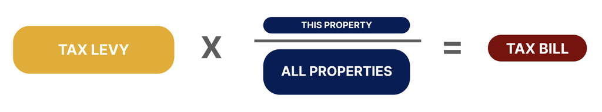

Property tax bills are calculated based on the **Tax Levy** and the value of your property. First, the government determines the **Tax Levy**, or total amount of taxes imposed by the government. This levy is then divided among all property owners in the area. Your share of this levy depends on **how much your property is worth compared to the total value of all properties**.

Your final tax bill reflects your property’s **share of the total taxable value** in the area, meaning you contribute to the Tax Levy in proportion to your property’s worth.

## How did this property’s change in price affect my bill?

This share is how much this property’s taxable value, or its Equalized Assessed Value, makes up of the the taxable value of all properties, called the Tax Base. The Tax Base is the combination of the taxable value of all residential and commercial properties.

This share can be broken up into two parts that impact your bill:

**(A) This Property’s Share of all Residential Properties**

**(B) Commercial-Residential Ratio**

#### (A) This Property’s Share of all Residential Properties

One reason your tax bill changing is due to the change in your property’s taxable value compared to all other properties in your area. Your property’s taxable value **increased** by **3.17%**.

Your property’s taxable value is called the Equalized Assessed Value (EAV) and is calculated using the property’s fair market value (as determined by the Cook County Assessor’s Office), any exemptions the property claims, and the state equalization factor. See Appendix A for more details).

More important than how this specific property’s value changed is how much it changed value compared to all other properties in your area. From 2022 to 2023 this property’s taxable value increased by less than other properties in your area. This caused your tax bill to **decrease** by **$177.58**.

**District wise changes in EAV Residential Share**

|  | Tax District | EAV Residential Share Prior | EAV Residential Share Current | Change in EAV Residential Share | Change in Tax amount |  |
| --- | --- | --- | --- | --- | --- | --- |
| Cook County | County Of Cook | 3.57% | 3.37% | −5.49% | −$100.34 |  |
|  | Forest Preserve District Of Cook County | 3.57% | 3.37% | −5.49% | −$18.86 |  |
| Municipality/Township | City Of Chicago | 7.33% | 7.34% | 0.10% | $7.08 |  |
|  | City Of Chicago Library Fund | 7.33% | 7.34% | 0.10% | $0.57 |  |
|  | City Of Chicago School Bldg & Imp Fund | 7.33% | 7.34% | 0.10% | $0.67 |  |
| School | Chicago Community College District 508 | 7.34% | 7.34% | 0.10% | $0.68 |  |
|  | Board Of Education | 7.33% | 7.34% | 0.10% | $16.33 |  |
| Miscellaneous | Chicago Park District | 7.33% | 7.34% | 0.10% | $1.40 |  |
|  | Metro Water Reclamation District Of Greater Chicago | 3.64% | 3.44% | −5.37% | −$85.11 |  |
| Total Tax Owed | — | — | — | — | −$177.58 | — |

#### (B) Commercial-Residential Ratio

A second part of your tax bill changing is due to how much **all** residential properties pay compared to **all** commercial properties. Commercial properties are more likely to decrease their assessment value through appeals, which shifts the tax burden more onto residential properties. The share that all residential properties paid in 2023 increased causing a **$100.60 increase** in your tax bill.

**District wise changes in Commercial Share**

|  | Tax District | Commercial Share Prior | Commercial Share Current | Change in Commercial Share | Change in Tax amount |  |
| --- | --- | --- | --- | --- | --- | --- |
| Cook County | County Of Cook | 35.62% | 34.85% | −2.17% | $21.97 |  |
|  | Forest Preserve District Of Cook County | 35.62% | 34.85% | −2.17% | $4.13 |  |
| Municipality/Township | City Of Chicago | 40.34% | 40.22% | −0.32% | $14.71 |  |
|  | City Of Chicago Library Fund | 40.34% | 40.22% | −0.32% | $1.20 |  |
|  | City Of Chicago School Bldg & Imp Fund | 40.34% | 40.22% | −0.32% | $1.39 |  |
| School | Chicago Community College District 508 | 40.32% | 40.20% | −0.32% | $1.40 |  |
|  | Board Of Education | 40.34% | 40.22% | −0.32% | $33.94 |  |
| Miscellaneous | Chicago Park District | 40.34% | 40.22% | −0.32% | $2.91 |  |
|  | Metro Water Reclamation District Of Greater Chicago | 35.85% | 35.09% | −2.14% | $18.95 |  |
| Total Tax Owed | — | — | — | — | $100.60 | — |

## How did a change in the Tax Levy affect my bill?

Lastly, your tax bill may have also changed due to the change in the **Tax Levy**, or the total amount of taxes imposed by the government. The total **Tax Levy** for all tax districts for this property **increased** by **2.35%** between 2023 and 2022. This increase resulted in a **increase** of **$843.01** in your tax bill.

**District wise changes in Levies**

|  | Tax District | Tax Levy Prior | Tax Levy Current | Change in Tax Levy | Change in Tax amount |  |
| --- | --- | --- | --- | --- | --- | --- |
| Cook County | County Of Cook | $795.79M | $768.76M | −3.40% | −$62.07 |  |
|  | Forest Preserve District Of Cook County | $149.56M | $149.37M | −0.13% | −$0.43 |  |
| Municipality/Township | City Of Chicago | $1.58B | $1.61B | 1.83% | $126.42 |  |
|  | City Of Chicago Library Fund | $128.87M | $128.54M | −0.25% | −$1.42 |  |
|  | City Of Chicago School Bldg & Imp Fund | $148.24M | $142.49M | −3.88% | −$25.16 |  |
| School | Chicago Community College District 508 | $150.11M | $157.36M | 4.83% | $31.76 |  |
|  | Board Of Education | $3.64B | $3.82B | 4.81% | $766.64 |  |
| Miscellaneous | Chicago Park District | $312.96M | $316.87M | 1.25% | $17.12 |  |
|  | Metro Water Reclamation District Of Greater Chicago | $679.35M | $675.12M | −0.62% | −$9.85 |  |
| Total Tax Owed | — | — | — | — | $843.01 | — |

**Appendix A: Calculating Equalized Assessed Value**

First, start with the Fair Market Value and multiply by the Level of Assessment, which is 10% for all residential property, and the State Equalizer, a multiplier whose goal is to make property tax rates roughly equal across all IL counties. Both of these values are the same for all property owners in this area. After this, subtract your valid exemptions. [^1]

The resulting value is the Equalized Assessed Value.
$$\$1.45M \times 10.00\% \times 3.0163 = \$437.36K$$
$$\$437.36K - \$0 = \$437.36K$$

**Appendix B: Properties Tax Districts**

This property is a part of many tax districts. Your actual bill is calculated but taking the tax levy times your property’s taxable value (EAV) divided by the sum of all taxable property (Tax Base) for *each tax district* you property in in. See each tax district your property is in, including the district’s total tax base, levy, and the taxes owned to this district. See Appendix C below for a more detailed explanation for how your tax bill is calculated for each district.

|  | Tax District | Agency Tax Base | Agency Tax Levy | Agency Tax Rate | Final Tax Owed |
| --- | --- | --- | --- | --- | --- |
| School | Board Of Education | $99.65B | $3.82B | 3.83% | $16,746.67 |
|  | Chicago Community College District 508 | $99.60B | $157.36M | 0.16% | $691.04 |
| Municipality/Township | City Of Chicago | $99.65B | $1.61B | 1.61% | $7,050.31 |
|  | City Of Chicago School Bldg & Imp Fund | $99.65B | $142.49M | 0.14% | $625.43 |
|  | City Of Chicago Library Fund | $99.65B | $128.54M | 0.13% | $564.20 |
| Miscellaneous | Metro Water Reclamation District Of Greater Chicago | $195.69B | $675.12M | 0.35% | $1,508.91 |
|  | Chicago Park District | $99.65B | $316.87M | 0.32% | $1,390.82 |
|  | Southeast Expanded Mental Health Service District | $2.19B | $548.61K | 0.02% | $109.34 |
| Cook County | County Of Cook | $199.16B | $768.76M | 0.39% | $1,688.23 |
|  | Forest Preserve District Of Cook County | $199.16B | $149.37M | 0.07% | $328.02 |

**Appendix C: Calaculating a Single District’s Tax Bill**

Your property is in many tax districts.

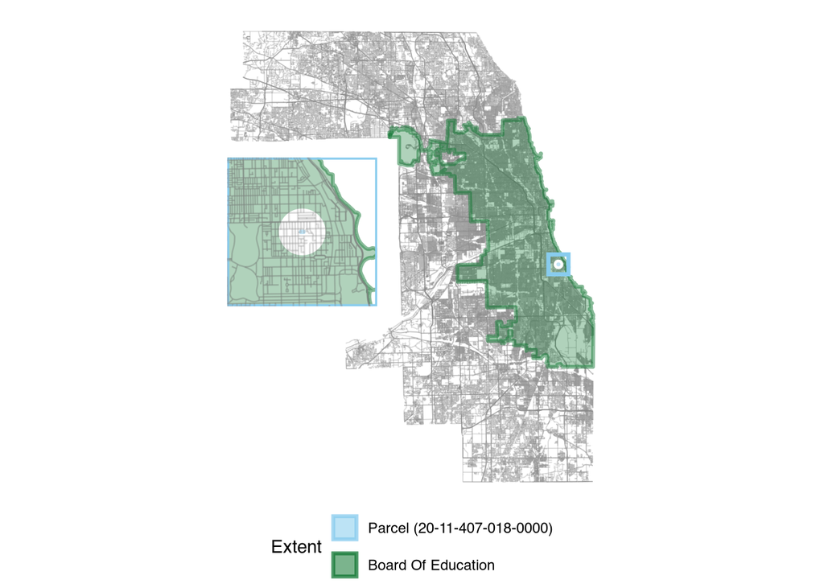

Now, let’s look at the line item of the bill for **Parcel (20-11-407-018-0000)** in 2023 for **Board Of Education** -

|  | Tax District | Agency Tax Base | Agency Tax Levy | Agency Tax Rate | Final Tax Owed |
| --- | --- | --- | --- | --- | --- |
| School | Board Of Education | $99.65B | $3.82B | 3.83% | $16,746.67 |

For the purpose of operating **Board Of Education**, in 2023, it needs to collect **$3.82b** in order to provide services.

|  | Tax District | Agency Tax Base | Agency Tax Levy | Agency Tax Rate | Final Tax Owed |
| --- | --- | --- | --- | --- | --- |
| School | Board Of Education | $99.65B | $3.82B | 3.83% | $16,746.67 |

But where can **Board Of Education** raise the money from? From all the properties within the district boundaries!  
The total taxable value of all properties falling in **Board Of Education** make up its **tax base**. For 2023, this was **$99.65b**

|  | Tax District | Agency Tax Base | Agency Tax Levy | Agency Tax Rate | Final Tax Owed |
| --- | --- | --- | --- | --- | --- |
| School | Board Of Education | $99.65B | $3.82B | 3.83% | $16,746.67 |

The cost of services of **Board Of Education** is therefore divided amongst all the property owners, and **Board Of Education** sets its agency tax rate equal to:

$$\mathrm{{Levy \over Base} = Tax \hspace{0.1cm} rate}$$

Using real numbers, the tax rate equals:
$$\mathrm{\$3.82B \over \$99.65B} = 3.83\%$$

|  | Tax District | Agency Tax Base | Agency Tax Levy | Agency Tax Rate | Final Tax Owed |
| --- | --- | --- | --- | --- | --- |
| School | Board Of Education | $99.65B | $3.82B | 3.83% | $16,746.67 |

#### How much do you owe **Board Of Education**?

As the owner of **Parcel (20-11-407-018-0000)**, in the year 2023 your property is worth **$1.45m**, of that, your taxable amount (or addition to the tax base) is **$437.36k**[^2].

The previously calculated **Rate** is then applied to your **Addition To The Tax Base**:

$$(\$437.36K * 3.83\%) = \$16.75K$$

This is the total tax amount you owe to **Board Of Education**

|  | Tax District | Agency Tax Base | Agency Tax Levy | Agency Tax Rate | Final Tax Owed |
| --- | --- | --- | --- | --- | --- |
| School | Board Of Education | $99.65B | $3.82B | 3.83% | $16,746.67 |

That was the whole first line!

> Generally, these districts fund the local elementary, middle and high schools, along with community colleges in the area.

> The **Board Of Education** is partially funded by property taxes and runs the Chicago Public Schools system, a K-12 system in the City of Chicago.

> [Chicago Public Schools, Revenue, 2023](https://www.cps.edu/about/finance/budget/budget-2023/revenue/)

## Footnotes

[^1]: This property currently has NO exemptions applied -

    | Exemption Type | Exemption Active |
    | --- | --- |
    | Homeowner |  |
    | Senior |  |
    | Freeze |  |
    | Longtime Homeowner |  |
    | Disabled |  |
    | Vet Returning |  |
    | Vet Dis Lt50 |  |
    | Vet Dis 50 69 |  |
    | Vet Dis Ge70 |  |
    | Abate |  |

[^2]: This property currently has NO exemptions applied -

    | Exemption Type | Exemption Active |
    | --- | --- |
    | Homeowner |  |
    | Senior |  |
    | Freeze |  |
    | Longtime Homeowner |  |
    | Disabled |  |
    | Vet Returning |  |
    | Vet Dis Lt50 |  |
    | Vet Dis 50 69 |  |
    | Vet Dis Ge70 |  |
    | Abate |  |